# Geo-Visual Analytics: Site Selection for Starbucks

### Look for the datasets of interest using the Data Discovery methods

More documentation here: https://carto.com/developers/cartoframes/guides/Data-discovery/

Let's start by exploring the Data Catalog to see what data categories CARTO can offer for data in the US.

```python
Catalog().country('usa').categories
```

```
[<Category.get('behavioral')>,
 <Category.get('covid19')>,
 <Category.get('demographics')>,
 <Category.get('derived')>,
 <Category.get('environmental')>,
 <Category.get('financial')>,
 <Category.get('housing')>,
 <Category.get('human_mobility')>,
 <Category.get('points_of_interest')>,
 <Category.get('road_traffic')>]
```

```python
Catalog().country('usa').category('demographics').datasets.to_dataframe().provider_id.unique()
```

```
array(['ags', 'worldpop', 'experian', 'usa_acs', 'usa_bls', 'mbi',
       'gbr_cdrc'], dtype=object)
```

Let's select **usa_acs** provider from the previous ones and check the catalogue of enriched data available.

```python
catalog_usa_demo = Catalog().country('usa').category('demographics').datasets.to_dataframe()
catalog_usa_demo_acs = catalog_usa_demo[catalog_usa_demo.provider_id == 'usa_acs']
catalog_usa_demo_acs.geography_name.unique()
```

```
array(['Census Tract - United States of America (2015)',
       'Core-based Statistical Area - United States of America (2019)',
       'Census Place - United States of America (2019)',
       'Congressional District - United States of America (2019)',
       'State - United States of America (2015)',
       'School District (unified) - United States of America (2019)',
       'Public Use Microdata Area - United States of America (2019)',
       'County - United States of America (2015)',
       'School District (secondary) - United States of America (2019)',
       'School District (elementary) - United States of America (2019)',
       '5-digit Zip Code Tabulation Area - United States of America (2015)',
       'Census Block Group - United States of America (2015)'],
      dtype=object)
```

Now, let's select the data from **'Census Block Group - United States of America (2015)'**

```python
catalog_usa_demo_acs_bk = catalog_usa_demo_acs[catalog_usa_demo_acs.geography_name == 'Census Block Group - United States of America (2015)']
```

```python
catalog_usa_demo_acs_bk.id.to_list()
```

```
['carto-do-public-data.usa_acs.demographics_sociodemographics_usa_blockgroup_2015_5yrs_20132017',
 'carto-do-public-data.usa_acs.demographics_sociodemographics_usa_blockgroup_2015_5yrs_20142018',
 'carto-do-public-data.usa_acs.demographics_sociodemographics_usa_blockgroup_2015_5yrs_20122016',
 'carto-do-public-data.usa_acs.demographics_sociodemographics_usa_blockgroup_2015_5yrs_20082012',
 'carto-do-public-data.usa_acs.demographics_sociodemographics_usa_blockgroup_2015_5yrs_20072011',
 'carto-do-public-data.usa_acs.demographics_sociodemographics_usa_blockgroup_2015_5yrs_20112015',
 'carto-do-public-data.usa_acs.demographics_sociodemographics_usa_blockgroup_2015_5yrs_20102014',
 'carto-do-public-data.usa_acs.demographics_sociodemographics_usa_blockgroup_2015_5yrs_20092013',
 'carto-do-public-data.usa_acs.demographics_sociodemographics_usa_blockgroup_2015_5yrs_20062010']
```

To explore in greater detail the metadata associated to this table, we can use the `Dataset`command from Carto as follows:

```python
Dataset.get('carto-do-public-data.usa_acs.demographics_sociodemographics_usa_blockgroup_2015_5yrs_20132017').to_dict()
```

```
{'slug': 'acs_sociodemogr_b758e778',
 'name': 'Sociodemographics - United States of America (Census Block Group, 2017, 5yrs)',
 'description': 'The American Community Survey (ACS) is an ongoing survey that provides vital information on a yearly basis about the USA and its people. This dataset contains only a subset of the variables that have been deemed most relevant. More info: https://www.census.gov/programs-surveys/acs/a…
 'category_id': 'demographics',
 'country_id': 'usa',
 'data_source_id': 'sociodemographics',
 'provider_id': 'usa_acs',
 'geography_name': 'Census Block Group - United States of America (2015)',
 'geography_description': 'Shoreline clipped TIGER/Line boundaries. More info: https://carto.com/blog/tiger-shoreline-clip/',
 'temporal_aggregation': '5yrs',
 'time_coverage': '[2013-01-01, 2018-01-01)',
 'update_frequency': 'yearly',
 'is_public_data': True,
 'lang': 'eng',
 'version': '20132017',
 'category_name': 'Demographics',
 'provider_name': 'American Community Survey',
 'geography_id': 'carto-do-public-data.carto.geography_usa_blockgroup_2015',
 'id': 'carto-do-public-data.usa_acs.demographics_sociodemographics_usa_blockgroup_2015_5yrs_20132017'}
```

[**EX10**] According to the data description which is the main characteristics of the census block data in terms of time aggregation, private or public, updating periodicity, etc....?

```python
print('This census block data has a temporal aggregation of 5 years, from 2013 to 2018 (not included). The data is public. ')
```

```
This census block data has a temporal aggregation of 5 years, from 2013 to 2018 (not included). The data is public.
```

If we do the same exploration for the geometries associated to the selected census block, we should use the `Geography` method from Carto as follows:

```python
Geography.get('carto-do-public-data.carto.geography_usa_blockgroup_2015').to_dict()
```

```
{'slug': 'cdb_blockgroup_7753dd51',
 'name': 'Census Block Group - United States of America (2015)',
 'description': 'Shoreline clipped TIGER/Line boundaries. More info: https://carto.com/blog/tiger-shoreline-clip/',
 'country_id': 'usa',
 'provider_id': 'carto',
 'geom_type': 'MULTIPOLYGON',
 'update_frequency': None,
 'is_public_data': True,
 'lang': 'eng',
 'version': '2015',
 'provider_name': 'CARTO',
 'id': 'carto-do-public-data.carto.geography_usa_blockgroup_2015'}
```

Finally, we will build the query to get the Census data and Census geometries of the polygons that interesects with the **Long Island geometry** previously defined. To do it, we apply the following code:

```python
df_X = Dataset.get('acs_sociodemogr_b758e778')
q = "select * from $dataset$ where ST_Intersects(geom,st_geogfromtext('{}'))".format(aoi.geometry.astype(str)[0])
df_X = df_X.to_dataframe(sql_query=q)
df_X['geometry'] = df_X['geom'].apply(lambda x: str_to_geom(x))
df_X = GeoDataFrame(df_X,geometry = df_X.geometry)
df_X.crs = {'init' :'epsg:4326'}
df_X.to_crs(epsg=4326, inplace=True)
df_X.head(3)
```

|  | geoid | do_date | total_pop | households | male_pop | female_pop | median_age | male_under_5 | male_5_to_9 | male_10_to_14 | ... | pop_in_labor_force | not_in_labor_force | armed_forces | civilian_labor_force | do_label | do_perimeter | do_area | do_num_vertices | geom | geometry |
| --- | --- | --- | --- | --- | --- | --- | --- | --- | --- | --- | --- | --- | --- | --- | --- | --- | --- | --- | --- | --- | --- |
| 0 | 360470340002 | 2013-01-01 | 720.0 | 139.0 | 298.0 | 422.0 | 83.1 | 0.0 | 0.0 | 0.0 | ... | 0.0 | 720.0 | 0.0 | 0.0 | Block Group 2 | 909.463 | 47648.525 | 9 | POLYGON((-73.994726 40.57152, -73.993577 40.57... | POLYGON ((-73.99473 40.57152, -73.99358 40.571... |
| 1 | 360471058042 | 2013-01-01 | 784.0 | 586.0 | 316.0 | 468.0 | 80.0 | 0.0 | 0.0 | 0.0 | ... | 14.0 | 770.0 | 0.0 | 14.0 | Block Group 2 | 1206.945 | 89274.575 | 9 | POLYGON((-73.889591 40.651338, -73.889994 40.6... | POLYGON ((-73.88959 40.65134, -73.88999 40.651... |
| 2 | 360810085002 | 2013-01-01 | 79.0 | 35.0 | 54.0 | 25.0 | 32.8 | 0.0 | 0.0 | 3.0 | ... | 52.0 | 13.0 | 0.0 | 52.0 | Block Group 2 | 1480.301 | 126149.190 | 10 | POLYGON((-73.94435 40.756875, -73.942822 40.75... | POLYGON ((-73.94435 40.75688, -73.94282 40.756... |

3 rows × 171 columns

[**EX11**] Plot a map with df_X resulting from the interesetion of the Census Blocks and Long Island Geometry.

```python
## Map(Layer(df_X))
```

```
WARNING: 1 intermediate output message was discarded.
```

[**EX12**] Filter the first 1000 census block in df_X and build the same map as before. What's the difference respect to **EX11**? Why?

```python
print('Now only a 1000 census blocks are painted as we are not taking the whole dataframe.')
## Map(Layer(df_X[:1000]))
```

```
Now only a 1000 census blocks are painted as we are not taking the whole dataframe.
```

[interactive chart not shown]

## 4. Data wrangling: normalization and dimensionality reduction

### Normalization of extensive variables by the total population

When comparing data for irregular units like census block groups, extra care is needed for extensive variables, i.e. one whose value for a block can be viewed as a sum of sub-block values, as in the case of population. For extensive variables in fact we need first to normalize them, e.g. by dividing by the total area or the total population, depending on the application. Using the metadata available in CARTO Data Observatory we will check which of all the variables can be considered extensive by looking at their default aggregation method: if the aggregation method is classified as SUM, then the variable is normalized by dividing by the total population.

```python
## Get the default aggregation methods
agg_methods_table = read_carto("""
                            SELECT column_name,
                                    agg_method
                            FROM variables_public
                            WHERE dataset_id = 'carto-do-public-data.usa_acs.demographics_sociodemographics_usa_blockgroup_2015_5yrs_20132017'""",
                            credentials = Credentials(username='do-metadata', api_key='default_public'))
agg_methods_table.dropna(inplace = True)
agg_methods_table.head()
```

|  | column_name | agg_method |
| --- | --- | --- |
| 0 | male_18_to_19 | SUM |
| 1 | associates_degree | SUM |
| 2 | income_100000_124999 | SUM |
| 3 | families_with_young_children | SUM |
| 4 | two_parents_not_in_labor_force_families_with_y... | SUM |

[**EX13**] For census block dataset, **df_X**, compute densities (i.e. column value divided by the the total population) for each numerical column that appears in `agg_methods_table`. Store the new value in a column with **'_dens'** suffix and delete the original one.

```python
sum_var = agg_methods_table[agg_methods_table.agg_method == 'SUM']['column_name']

for item in sum_var:
    if item != 'total_pop':
        df_X[item] = df_X[item]/df_X["total_pop"]
        df_X[item+'_dens']=df_X[item]
        del df_X[item]
df_X
```

|  | geoid | do_date | total_pop | median_income | income_per_capita | renter_occupied_housing_units_paying_cash_median_gross_rent | owner_occupied_housing_units_lower_value_quartile | owner_occupied_housing_units_median_value | owner_occupied_housing_units_upper_value_quartile | median_year_structure_built | ... | rent_35_to_40_percent_dens | one_year_more_college_dens | female_21_dens | female_80_to_84_dens | income_45000_49999_dens | commute_10_14_mins_dens | female_50_to_54_dens | female_65_to_66_dens | income_20000_24999_dens | owner_occupied_housing_units_dens |
| --- | --- | --- | --- | --- | --- | --- | --- | --- | --- | --- | --- | --- | --- | --- | --- | --- | --- | --- | --- | --- | --- |
| 0 | 360470340002 | 2013-01-01 | 720.0 | 11341.0 | 12284.0 | 247.0 | NaN | NaN | NaN | 1994.0 | ... | 0.000000 | 0.027778 | 0.000000 | 0.163889 | 0.000000 | 0.000000 | 0.000000 | 0.019444 | 0.025000 | 0.009722 |
| 1 | 360471058042 | 2013-01-01 | 784.0 | 12646.0 | 11530.0 | 322.0 | NaN | NaN | NaN | 1989.0 | ... | 0.038265 | 0.053571 | 0.000000 | 0.214286 | 0.017857 | 0.000000 | 0.000000 | 0.000000 | 0.093112 | 0.000000 |
| 2 | 360810085002 | 2013-01-01 | 79.0 | NaN | 11085.0 | 1631.0 | NaN | NaN | NaN | 1939.0 | ... | 0.037975 | 0.000000 | 0.000000 | 0.000000 | 0.000000 | 0.000000 | 0.000000 | 0.000000 | 0.000000 | 0.000000 |
| 3 | 360811417005 | 2013-01-01 | 142.0 | 45833.0 | 20522.0 | 1319.0 | NaN | NaN | NaN | 1969.0 | ... | 0.105634 | 0.140845 | 0.000000 | 0.063380 | 0.063380 | 0.000000 | 0.070423 | 0.000000 | 0.000000 | 0.133803 |
| 4 | 360470900001 | 2013-01-01 | 401.0 | 41417.0 | 19454.0 | 1175.0 | 354000.0 | 483300.0 | 623100.0 | 1965.0 | ... | 0.000000 | 0.052369 | 0.057357 | 0.000000 | 0.000000 | 0.000000 | 0.049875 | 0.000000 | 0.000000 | 0.167082 |
| ... | ... | ... | ... | ... | ... | ... | ... | ... | ... | ... | ... | ... | ... | ... | ... | ... | ... | ... | ... | ... | ... |
| 5892 | 361031457041 | 2013-01-01 | 2075.0 | 67833.0 | 27509.0 | NaN | 164000.0 | 211600.0 | 275800.0 | 1974.0 | ... | 0.000000 | 0.048193 | 0.000000 | 0.008193 | 0.006747 | 0.034217 | 0.028916 | 0.000000 | 0.000000 | 0.185542 |
| 5893 | 361031467032 | 2013-01-01 | 1898.0 | 84091.0 | 31188.0 | NaN | 244200.0 | 280300.0 | 332500.0 | 1957.0 | ... | 0.000000 | 0.079031 | 0.006322 | 0.010537 | 0.011064 | 0.096944 | 0.036354 | 0.010011 | 0.011064 | 0.296101 |
| 5894 | 361031121032 | 2013-01-01 | 1887.0 | 84107.0 | 37040.0 | NaN | 349000.0 | 397900.0 | 469100.0 | 1959.0 | ... | 0.000000 | 0.059883 | 0.007419 | 0.008479 | 0.005299 | 0.104399 | 0.067833 | 0.029677 | 0.013778 | 0.325914 |
| 5895 | 361031590001 | 2013-01-01 | 2347.0 | 68824.0 | 27357.0 | NaN | 267900.0 | 323400.0 | 378000.0 | 1962.0 | ... | 0.000000 | 0.106093 | 0.003409 | 0.029399 | 0.004261 | 0.060929 | 0.056668 | 0.025991 | 0.005113 | 0.222412 |
| 5896 | 361031352011 | 2013-01-01 | 2165.0 | 133083.0 | 46157.0 | NaN | 382700.0 | 441000.0 | 490200.0 | 1956.0 | ... | 0.000000 | 0.065589 | 0.001386 | 0.014319 | 0.002771 | 0.101617 | 0.045266 | 0.002309 | 0.010162 | 0.313626 |

5897 rows × 171 columns

```python
df_X.columns.values
```

```
array(['geoid', 'do_date', 'total_pop', 'median_income',
       'income_per_capita',
       'renter_occupied_housing_units_paying_cash_median_gross_rent',
       'owner_occupied_housing_units_lower_value_quartile',
       'owner_occupied_housing_units_median_value',
       'owner_occupied_housing_units_upper_value_quartile',
       'median_year_structure_built', 'median_rent',
       'percent_income_spent_on_rent', 'do_label', 'do_perimeter',
       'do_area', 'do_num_vertices', 'geom', 'geometry',
       'male_18_to_19_dens', 'associates_degree_dens',
       'income_100000_124999_dens', 'families_with_young_children_dens',
       'two_parents_not_in_labor_force_families_with_young_children_dens',
       'commute_45_59_mins_dens', 'male_25_to_29_dens', 'black_pop_dens',
       'million_dollar_housing_units_dens', 'not_in_labor_force_dens',
       'female_25_to_29_dens', 'two_or_more_races_pop_dens',
       'income_35000_39999_dens', 'rent_burden_not_computed_dens',
       'male_70_to_74_dens', 'female_75_to_79_dens',
       'rent_10_to_15_percent_dens', 'pop_in_labor_force_dens',
       'asian_pop_dens', 'amerindian_pop_dens',
       'black_including_hispanic_dens', 'income_30000_34999_dens',
       'households_retirement_income_dens',
       'vacant_housing_units_for_rent_dens', 'female_62_to_64_dens',
       'other_race_pop_dens', 'income_50000_59999_dens',
       'rent_20_to_25_percent_dens', 'less_one_year_college_dens',
       'male_40_to_44_dens', 'hispanic_pop_dens',
       'commute_35_44_mins_dens', 'commute_90_more_mins_dens',
       'rent_40_to_50_percent_dens', 'male_67_to_69_dens',
       'income_15000_19999_dens', 'income_40000_44999_dens',
       'nonfamily_households_dens', 'median_age_dens',
       'vacant_housing_units_dens', 'dwellings_2_units_dens',
       'male_15_to_17_dens', 'male_55_to_59_dens', 'male_60_to_61_dens',
       'female_5_to_9_dens', 'income_less_10000_dens',
       'dwellings_5_to_9_units_dens', 'commute_20_24_mins_dens',
       'female_35_to_39_dens', 'occupied_housing_units_dens',
       'dwellings_1_units_detached_dens', 'commute_15_19_mins_dens',
       'commute_60_more_mins_dens', 'male_80_to_84_dens',
       'bachelors_degree_dens', 'male_35_to_39_dens',
       'female_15_to_17_dens', 'female_70_to_74_dens',
       'income_75000_99999_dens', 'income_125000_149999_dens',
       'dwellings_10_to_19_units_dens', 'family_households_dens',
```

[output cut: 34 more lines]

```
       'high_school_diploma_dens', 'civilian_labor_force_dens',
       'male_50_to_54_dens', 'female_67_to_69_dens',
       'pop_25_years_over_dens', 'housing_units_renter_occupied_dens',
       'dwellings_20_to_49_units_dens', 'commuters_16_over_dens',
       'masters_degree_dens', 'employed_pop_dens',
       'housing_built_2000_to_2004_dens',
       'housing_built_1939_or_earlier_dens', 'male_pop_dens',
       'pop_16_over_dens', 'two_parent_families_with_young_children_dens',
       'armed_forces_dens', 'male_85_and_over_dens',
       'rent_35_to_40_percent_dens', 'one_year_more_college_dens',
       'female_21_dens', 'female_80_to_84_dens',
       'income_45000_49999_dens', 'commute_10_14_mins_dens',
       'female_50_to_54_dens', 'female_65_to_66_dens',
       'income_20000_24999_dens', 'owner_occupied_housing_units_dens'],
      dtype=object)
```

[**EX14**] Delete unused columns with the following characteristics:

- They are not float
- They have the suffix 'do-'
- `total_pop`should not be

We should keep the variables `geo_id` and `geometry`.

```python
for col in df_X.columns:
  if col not in ["geoid", "geometry"]:
    if col not in df_X.select_dtypes(include=['float64']):
      del df_X[col]
    if "do-" in col:
      del df_X[col]

df_X.drop(['total_pop'], axis = 1, inplace=True)

df_X.head(3)
```

|  | geoid | median_income | income_per_capita | renter_occupied_housing_units_paying_cash_median_gross_rent | owner_occupied_housing_units_lower_value_quartile | owner_occupied_housing_units_median_value | owner_occupied_housing_units_upper_value_quartile | median_year_structure_built | median_rent | percent_income_spent_on_rent | ... | rent_35_to_40_percent_dens | one_year_more_college_dens | female_21_dens | female_80_to_84_dens | income_45000_49999_dens | commute_10_14_mins_dens | female_50_to_54_dens | female_65_to_66_dens | income_20000_24999_dens | owner_occupied_housing_units_dens |
| --- | --- | --- | --- | --- | --- | --- | --- | --- | --- | --- | --- | --- | --- | --- | --- | --- | --- | --- | --- | --- | --- |
| 0 | 360470340002 | 11341.0 | 12284.0 | 247.0 | NaN | NaN | NaN | 1994.0 | 181.0 | 29.2 | ... | 0.000000 | 0.027778 | 0.0 | 0.163889 | 0.000000 | 0.0 | 0.0 | 0.019444 | 0.025000 | 0.009722 |
| 1 | 360471058042 | 12646.0 | 11530.0 | 322.0 | NaN | NaN | NaN | 1989.0 | 301.0 | 29.3 | ... | 0.038265 | 0.053571 | 0.0 | 0.214286 | 0.017857 | 0.0 | 0.0 | 0.000000 | 0.093112 | 0.000000 |
| 2 | 360810085002 | NaN | 11085.0 | 1631.0 | NaN | NaN | NaN | 1939.0 | 1620.0 | 50.0 | ... | 0.037975 | 0.000000 | 0.0 | 0.000000 | 0.000000 | 0.0 | 0.0 | 0.000000 | 0.000000 | 0.000000 |

3 rows × 166 columns

Let's store in `df_X_cols` variable a list of the columns in df_X except of `geoid`and `geometry`.

```python
df_X_cols = list(df_X.drop(['geoid','geometry'], axis = 1).columns)
```

Your dataframe should look like as:

```python
df_X.head()
```

|  | geoid | median_income | income_per_capita | renter_occupied_housing_units_paying_cash_median_gross_rent | owner_occupied_housing_units_lower_value_quartile | owner_occupied_housing_units_median_value | owner_occupied_housing_units_upper_value_quartile | median_year_structure_built | median_rent | percent_income_spent_on_rent | ... | rent_35_to_40_percent_dens | one_year_more_college_dens | female_21_dens | female_80_to_84_dens | income_45000_49999_dens | commute_10_14_mins_dens | female_50_to_54_dens | female_65_to_66_dens | income_20000_24999_dens | owner_occupied_housing_units_dens |
| --- | --- | --- | --- | --- | --- | --- | --- | --- | --- | --- | --- | --- | --- | --- | --- | --- | --- | --- | --- | --- | --- |
| 0 | 360470340002 | 11341.0 | 12284.0 | 247.0 | NaN | NaN | NaN | 1994.0 | 181.0 | 29.2 | ... | 0.000000 | 0.027778 | 0.000000 | 0.163889 | 0.000000 | 0.0 | 0.000000 | 0.019444 | 0.025000 | 0.009722 |
| 1 | 360471058042 | 12646.0 | 11530.0 | 322.0 | NaN | NaN | NaN | 1989.0 | 301.0 | 29.3 | ... | 0.038265 | 0.053571 | 0.000000 | 0.214286 | 0.017857 | 0.0 | 0.000000 | 0.000000 | 0.093112 | 0.000000 |
| 2 | 360810085002 | NaN | 11085.0 | 1631.0 | NaN | NaN | NaN | 1939.0 | 1620.0 | 50.0 | ... | 0.037975 | 0.000000 | 0.000000 | 0.000000 | 0.000000 | 0.0 | 0.000000 | 0.000000 | 0.000000 | 0.000000 |
| 3 | 360811417005 | 45833.0 | 20522.0 | 1319.0 | NaN | NaN | NaN | 1969.0 | 1319.0 | 37.2 | ... | 0.105634 | 0.140845 | 0.000000 | 0.063380 | 0.063380 | 0.0 | 0.070423 | 0.000000 | 0.000000 | 0.133803 |
| 4 | 360470900001 | 41417.0 | 19454.0 | 1175.0 | 354000.0 | 483300.0 | 623100.0 | 1965.0 | 1175.0 | 50.0 | ... | 0.000000 | 0.052369 | 0.057357 | 0.000000 | 0.000000 | 0.0 | 0.049875 | 0.000000 | 0.000000 | 0.167082 |

5 rows × 166 columns

### Any missing data?

Missing data are common in surveys, as the ACS. Before using the ACS data as covariates we therefore need to check if there are any missing data and to decide how to impute the missing values.

[**EX15**] Identify which variables have missing data and how many samples are missing.

```python
df_X.isnull().sum()
```

```
geoid                                                             0
median_income                                                   272
income_per_capita                                                41
renter_occupied_housing_units_paying_cash_median_gross_rent    1480
owner_occupied_housing_units_lower_value_quartile               873
                                                               ...
commute_10_14_mins_dens                                          34
female_50_to_54_dens                                             34
female_65_to_66_dens                                             34
income_20000_24999_dens                                          34
owner_occupied_housing_units_dens                                34
Length: 166, dtype: int64
```

[**EX16**] If we drop all samples with at least a missing value, which will be the size of this new dataframe? Justify if it is enough to continue with this new dataframe or not

```python
print(df_X.shape)
df_X_reduced = df_X.dropna()
print(df_X_reduced.shape)
print('The size of the new dataframe without the rows with Na values will only have 407 records out from 5897 it had previously. We are losing more than 90% of the data, there is no way we can continue, the results won\'t be significant and can be biased.')
```

```
(5897, 166)
(407, 166)
The size of the new dataframe without the rows with Na values will only have 407 records out from 5897 it had previously. We are losing more than 90% of the data, there is no way we can continue, the results won't be significant and can be biased.
```

### Are the variables correlated?

Next, we will check the pair-wise correlations between the ACS variables.

[**EX17**] Calculate and plot the correlation matrix for 50 variables randomly selected. What do you observe?

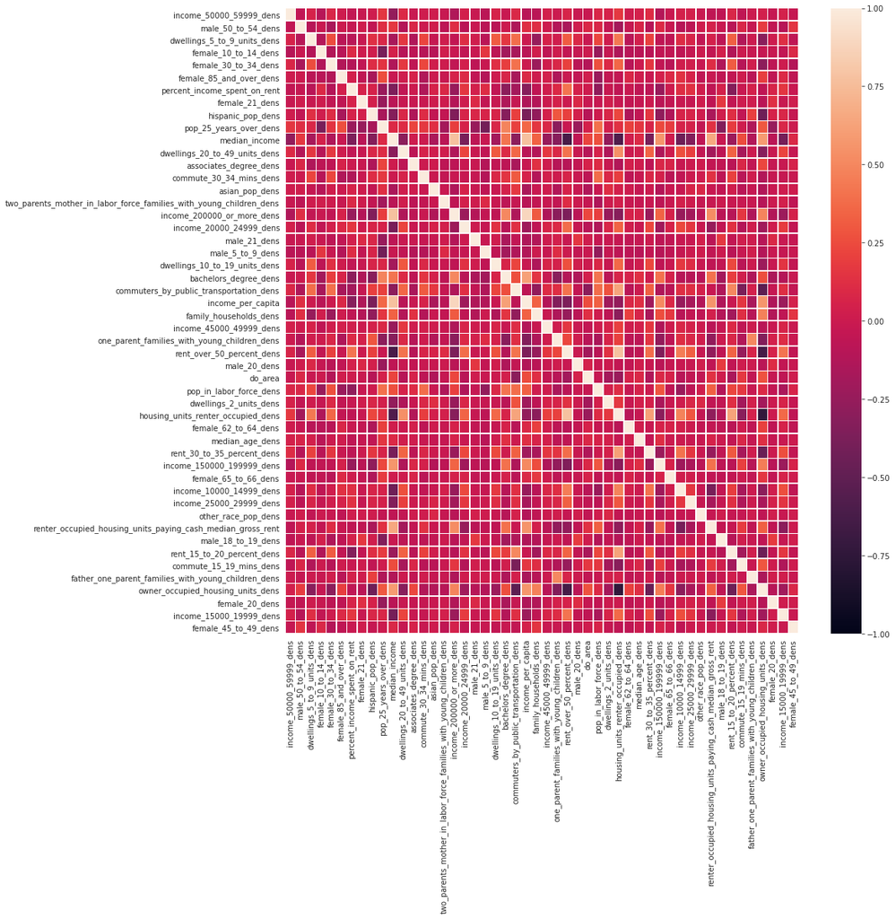

```
We observe that, in general, the correlation among variables is small. However we can see some exceptions with positive (close to 1.0) and negative (close to -1.0) correlated variables.
```

```python
def corr_heatmap(data):
    data_corr = data.corr().round(2)
    f, ax = plt.subplots(figsize=(15,15))
    sns.heatmap(data_corr,  vmin=-1, vmax=1, linewidths=.5, ax=ax)
    plt.show()

corr_heatmap(df_X.sample(n=50,axis='columns'))
print('We observe that, in general, the correlation among variables is small. However we can see some exceptions with positive (close to 1.0) and negative (close to -1.0) correlated variables.')
```

### To account for missing values and reduce the model dimensionality, we will transform the data using Priciple Component Analysis

To impute the missing data and reduce the model dimensionality we will use a probabilistic formulation of Principal Component Analysis (PCA). PCA is a technique to transform data sets of high dimensional vectors into lower dimensional ones that finds a smaller-dimensional linear representation of data vectors such that the original data could be reconstructed from the compressed representation with the minimum square error.

In its probabilistic formulation, probabilistic PCA (PPCA) the complete data are modelled by a generative latent variable model which iteratively updates the expected complete data log-likelihood and the maximum likelihood estimates of the parameters. In PPCA, the data are incomplete because the principal components are not observed and are treated as latent variables, which also allows to extend the method to when missing data are present.

More information can be found at http://www.jmlr.org/papers/volume11/ilin10a/ilin10a.pdf.

#### PPCA in a nutshell

PCA can also be described as the maximum likelihood solution of a probabilistic latent variable model, which is known as PPCA:

\begin{equation*} Y_{ij} = \mathbf{P}_i \, \mathbf{Z}_j + m_i + \varepsilon_{ij} \quad i = 1, .., d; \, j = 1, .., n \end{equation*}

with

\begin{align} p(\mathbf{Z}_j) \sim N(0, \mathbb{1}) \\ p(\varepsilon_{ij}) \sim N(0, \nu) \end{align}

Both the principal components $Z$ and the noise $\varepsilon$ are assumed normally distributed. The model can be identified by finding the maximum likelihood (ML) estimate for the model parameters using the Expectation-Maximization (EM) algorithm by minimizing the mean-square error of the observed part of the data. EM is a general framework for learning parameters with incomplete data which iteratively updates the expected complete data log-likelihood and the maximum likelihood estimates of the parameters. In PPCA, the data are incomplete because the principal components, $Z_i$, are not observed and are treated as latent variables. When missing data are present, in the E-step, the expectation of the complete-data log-likelihood is taken with respect to the conditional distribution of the latent variables given the observed variables. In this case, the update EM rules are the following.

1. E-step: \begin{align} \mathbf{\Sigma}_{\mathbf{Z}_j} = \nu \left(\nu \, \mathbb{1} + \sum_i \mathbf{P}_i \mathbf{P}_i^T \right)^{-1} \\ \overline{\mathbf{Z}}_j = \dfrac{1}{\nu}\mathbf{\Sigma}_{\mathbf{Z}_j} \sum_i \mathbf{P}_i \left(Y_{ij}- m_i \right) \\ m_{i} = \dfrac{1}{n} \sum_j \left(Y_{ij} - \mathbf{P}_i^T \, \overline{\mathbf{Z}}_j \right) \\ \end{align}
2. M-step: \begin{align} \mathbf{P}_{i} = \left( \sum_j \overline{\mathbf{Z}}_j \overline{\mathbf{Z}}_j ^T + \mathbf{\Sigma}_{\mathbf{Z}_j} \right)^{-1} \sum_j \overline{\mathbf{Z}}_j \, \left(Y_{ij}- m_{ij} \right)\\ \nu = \dfrac{1}{n} \sum_{ij} \left[ \left(Y_{ij} - \mathbf{P}_i^T \, \overline{\mathbf{Z}}_j - m_i \right)^2 + \mathbf{P}_i^T \, \overline{\mathbf{Z}}_j \mathbf{P}_i \, \right] \end{align}

where each row of $\mathbf{P}$ and $\overline{\mathbf{Z}}$ is recomputed based only on those columns of $\overline{\mathbf{Z}}$ which contribute to the reconstruction of the observed values in the corresponding row of the data matrix.

To impute missing values and extract PC scores (linearly decorrelated) we will use PPCA for our the `df_X_cols`of our dataframe as follows:

```python
X, var_exp = run_ppca(df_X, df_X_cols, min_obs = 0.8)
```

At the tail columns we can observe the Principal Component variables:

```python
X.head()
```

|  | geoid | median_income | income_per_capita | renter_occupied_housing_units_paying_cash_median_gross_rent | owner_occupied_housing_units_lower_value_quartile | owner_occupied_housing_units_median_value | owner_occupied_housing_units_upper_value_quartile | median_year_structure_built | median_rent | percent_income_spent_on_rent | ... | pc_127 | pc_128 | pc_129 | pc_130 | pc_131 | pc_132 | pc_133 | pc_134 | pc_135 | pc_136 |
| --- | --- | --- | --- | --- | --- | --- | --- | --- | --- | --- | --- | --- | --- | --- | --- | --- | --- | --- | --- | --- | --- |
| 0 | 360470340002 | 11341.0 | 12284.0 | 247.0 | NaN | NaN | NaN | 1994.0 | 181.0 | 29.2 | ... | -0.007402 | -0.267329 | -0.553755 | -0.499219 | 0.140436 | -0.707984 | -0.095309 | -0.022253 | -0.069363 | -0.020467 |
| 1 | 360471058042 | 12646.0 | 11530.0 | 322.0 | NaN | NaN | NaN | 1989.0 | 301.0 | 29.3 | ... | -0.172060 | -0.416468 | -0.630714 | 0.692891 | 0.031531 | 1.086017 | -0.026878 | -0.051493 | -0.545295 | 0.125613 |
| 2 | 360810085002 | NaN | 11085.0 | 1631.0 | NaN | NaN | NaN | 1939.0 | 1620.0 | 50.0 | ... | -0.241232 | -1.126270 | 0.253112 | 0.379541 | 0.208730 | -0.282311 | -0.645952 | 0.075613 | -0.065487 | -0.029871 |
| 3 | 360811417005 | 45833.0 | 20522.0 | 1319.0 | NaN | NaN | NaN | 1969.0 | 1319.0 | 37.2 | ... | 0.105176 | 0.466583 | 0.179606 | 0.055362 | 0.239443 | 0.219797 | -0.035361 | 0.234292 | 0.222040 | -0.029155 |
| 4 | 360470900001 | 41417.0 | 19454.0 | 1175.0 | 354000.0 | 483300.0 | 623100.0 | 1965.0 | 1175.0 | 50.0 | ... | 0.173744 | 0.298112 | -0.159614 | 0.298278 | 0.265272 | 0.203781 | 0.603363 | -0.329616 | -0.105994 | -0.022781 |

5 rows × 303 columns

[**EX18**] Plot the explained variance resulting from Principal Component Analysis. Tip: You can use the function **plot_pc_var(var_exp, textsize, title**). Which is the Principal Component that explains the most of the variance?

```
The Principal Component that explains most of the variance is the first one. The PC are sorted in decreasing order on explaining the variance.
```

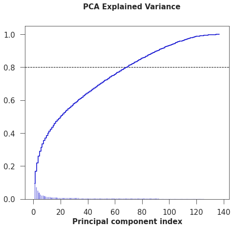

```python
plot_pc_var(var_exp, textsize=15, title='PCA Explained Variance')
print('The Principal Component that explains most of the variance is the first one. The PC are sorted in decreasing order on explaining the variance.')
```

We decide to keep the PCs up that explain up to 80% of the variance (the black dashed line in the plot below), but this choice is somewhat arbitrary and might vary depending on the application.

[**EX19**] To understand the relashionship between the transformed variables (the PC scores) and the original variable, we can plot the 4 variables most highly correlated with each PC. Use the function `plot_pc_corr (X, df_X_cols)`to plot these relationships. Which is the most positively correlated variable with PC0? Ant the most negatively correlated variable with PC0?

*Note: depending on the random seed on your computer, the signs of the correlations might change.*

```
The most positively correlated variable with PC0 is HOUSING UNITS RENTER OCCUPIED DENS with more than 0.75. On the other hand, the most negatively correlated variable is OWNER OCCUPIED HOUSING UNITS DENS with a similar absolute value.
```

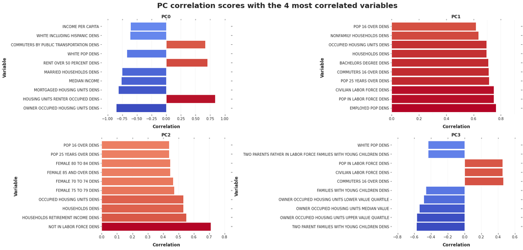

```python
plot_pc_corr(X, df_X_cols)
print('The most positively correlated variable with PC0 is HOUSING UNITS RENTER OCCUPIED DENS with more than 0.75. On the other hand, the most negatively correlated variable is OWNER OCCUPIED HOUSING UNITS DENS with a similar absolute value.')
```

[**EX20**] Create 3 maps as follows:

- One with the geo-visualization of the first `Principal Component`
- One with the geo-visualization of `owner_occupied_housing_units_dens` variable
- One with the geo-visualization of `housing_units_renter_occupied_dens`variable

```python
# geo-visualization of the first Principal Component
# Map([Layer(X,style=color_bins_style('pc_0'), encode_data=False)])
```

```
WARNING: 1 intermediate output message was discarded.
```

```python
# geo-visualization of `owner_occupied_housing_units_dens` variable
# Map([Layer(X,style=color_bins_style('owner_occupied_housing_units_dens'))])
```

```
WARNING: 1 intermediate output message was discarded.
```

```python
# geo-visualization of `housing_units_renter_occupied_dens`variable
# Map([Layer(X,style=color_bins_style('housing_units_renter_occupied_dens'))])
```

```
WARNING: 1 intermediate output message was discarded.
```

[**EX21**] Select only up the PC up to explain 80 % of the variance (dimensionality reduction)

```python
index_list = ['geoid', 'geometry', 'pc_0']

cum_var_exp = np.cumsum(var_exp)
for index in range (0, len(cum_var_exp)):
    if cum_var_exp[index] < 0.8:
        index_list.append('pc_' + str(index+1))


#drop_cols = np.setdiff1d(X.columns, index_list)

for col in X.columns:
    if col not in index_list:
        X.drop([col], axis = 1, inplace=True)

X
```

|  | geoid | geometry | pc_0 | pc_1 | pc_2 | pc_3 | pc_4 | pc_5 | pc_6 | pc_7 | ... | pc_59 | pc_60 | pc_61 | pc_62 | pc_63 | pc_64 | pc_65 | pc_66 | pc_67 | pc_68 |
| --- | --- | --- | --- | --- | --- | --- | --- | --- | --- | --- | --- | --- | --- | --- | --- | --- | --- | --- | --- | --- | --- |
| 0 | 360470340002 | POLYGON ((-73.99473 40.57152, -73.99358 40.571... | 0.559404 | -6.908538 | 14.735062 | -7.901487 | -2.427835 | 5.595734 | -5.171932 | 4.498502 | ... | -1.950631 | 0.348776 | 0.801331 | -0.574349 | -0.505093 | 0.774369 | -2.283671 | 0.559578 | 0.007618 | -0.146709 |
| 1 | 360471058042 | POLYGON ((-73.88959 40.65134, -73.88999 40.651... | 6.993617 | 0.129231 | 24.105093 | -13.807347 | -1.046774 | 1.164595 | -3.533382 | 5.192408 | ... | 2.346550 | 0.047911 | -5.535107 | -3.279021 | 1.067112 | -2.784222 | -1.688500 | 0.926626 | -1.392676 | 2.577099 |
| 2 | 360810085002 | POLYGON ((-73.94435 40.75688, -73.94282 40.756... | 7.293373 | 2.316299 | -1.587367 | -0.281509 | 3.490770 | 4.730380 | -2.753776 | -1.498218 | ... | 1.648538 | 1.949764 | 0.743265 | 1.141203 | -2.182980 | 0.015906 | 1.103304 | 0.038698 | -2.265194 | 1.313859 |
| 3 | 360811417005 | POLYGON ((-73.79723 40.74170, -73.79727 40.740... | 2.997390 | -2.093021 | 4.274223 | -3.839997 | 0.224379 | -1.414656 | -3.645954 | -3.406002 | ... | -0.716797 | 1.544626 | 0.240153 | 0.511747 | -1.402086 | 1.527858 | -1.742347 | -1.845593 | 3.177760 | 4.641683 |
| 4 | 360470900001 | POLYGON ((-73.91826 40.66857, -73.91722 40.664... | 4.259888 | -4.800530 | 2.958818 | 0.158746 | -2.756890 | -2.001692 | 6.411877 | 0.823422 | ... | -3.508735 | 1.336166 | 0.143500 | 0.540500 | -0.348818 | -2.216179 | -1.750566 | 1.425820 | 0.711947 | -2.491029 |
| ... | ... | ... | ... | ... | ... | ... | ... | ... | ... | ... | ... | ... | ... | ... | ... | ... | ... | ... | ... | ... | ... |
| 5892 | 361031457041 | POLYGON ((-73.19007 40.80020, -73.19013 40.799... | -1.073205 | -4.495927 | -1.942821 | 2.003686 | 2.956078 | -1.020185 | -0.566204 | 0.301432 | ... | -0.322835 | -0.636193 | 0.113329 | -1.012608 | 0.424731 | -0.098133 | -1.031075 | 0.662514 | 0.221623 | -0.759275 |
| 5893 | 361031467032 | POLYGON ((-73.30521 40.74090, -73.30455 40.740... | -2.929162 | -1.996071 | -1.558574 | 1.706757 | 2.235890 | -2.231739 | -0.144337 | -0.527786 | ... | -1.043892 | 0.449971 | 0.709522 | 0.277077 | 0.061942 | 0.479844 | 0.140910 | 0.445573 | -0.004618 | 0.508719 |
| 5894 | 361031121032 | POLYGON ((-73.31342 40.84017, -73.31293 40.838... | -5.252166 | -0.438449 | 0.841320 | 0.874311 | 1.911560 | -1.708018 | -0.987079 | 0.562970 | ... | -0.396561 | 0.830014 | 0.103353 | -0.925654 | 0.781510 | 0.040904 | 0.259554 | -0.074348 | 0.386426 | 0.052170 |
| 5895 | 361031590001 | POLYGON ((-73.01337 40.76174, -73.01250 40.759... | -0.547977 | -2.389447 | -0.064390 | 0.964480 | 3.012825 | -0.400226 | -0.640963 | 0.667340 | ... | -0.033455 | 0.182279 | 0.215250 | 0.630874 | 0.106424 | 0.632414 | -0.249004 | -0.638303 | -1.743886 | 0.568900 |
| 5896 | 361031352011 | POLYGON ((-73.28156 40.84333, -73.28156 40.842... | -6.229585 | 0.095186 | 0.038300 | 0.489465 | 1.380086 | -0.814124 | -0.032986 | 1.388186 | ... | -0.764257 | 0.296854 | 0.319785 | -0.126409 | 0.037046 | -0.355279 | -0.076809 | -0.348780 | -0.080620 | 0.175545 |

5897 rows × 71 columns

Your new `X` dataframe should look like as follows:

```python
X
```

|  | geoid | geometry | pc_0 | pc_1 | pc_2 | pc_3 | pc_4 | pc_5 | pc_6 | pc_7 | ... | pc_58 | pc_59 | pc_60 | pc_61 | pc_62 | pc_63 | pc_64 | pc_65 | pc_66 | pc_67 |
| --- | --- | --- | --- | --- | --- | --- | --- | --- | --- | --- | --- | --- | --- | --- | --- | --- | --- | --- | --- | --- | --- |
| 0 | 360470340002 | POLYGON ((-73.99473 40.57152, -73.99358 40.571... | 5.192626 | -2.843960 | -5.110736 | 10.490491 | -8.011965 | 0.400330 | -5.869855 | -1.035688 | ... | 0.427732 | 1.133546 | 1.126083 | 2.826179 | 0.120132 | 1.486582 | 1.188179 | 0.987515 | 0.894004 | 1.349302 |
| 1 | 360471058042 | POLYGON ((-73.88959 40.65134, -73.88999 40.651... | 1.034807 | -7.023206 | -0.529719 | 19.242748 | -11.120903 | 1.462790 | -3.346949 | 0.925443 | ... | -1.140199 | -1.632804 | -0.007739 | 0.527558 | -0.537280 | 0.422478 | -1.854992 | 3.283291 | 3.549802 | -0.887771 |
| 2 | 360810085002 | POLYGON ((-73.94435 40.75688, -73.94282 40.756... | 6.933532 | -6.891814 | 0.043945 | -2.201138 | 0.609429 | 2.362161 | -2.065274 | -2.664163 | ... | -0.155307 | -1.399615 | -0.614724 | -2.836122 | 0.304700 | 1.312867 | -0.182964 | -2.502034 | -2.559217 | 0.346803 |
| 3 | 360811417005 | POLYGON ((-73.79723 40.74170, -73.79727 40.740... | 6.825613 | -4.070425 | -1.726064 | 0.270334 | -3.478294 | 0.982270 | 1.479187 | -2.858226 | ... | 1.605078 | -0.109263 | -0.722469 | -0.637094 | 0.514089 | 0.275256 | 1.561046 | 0.047552 | 0.283640 | 3.289071 |
| 4 | 360470900001 | POLYGON ((-73.91826 40.66857, -73.91722 40.664... | 5.178326 | -6.088028 | -3.511389 | 0.878919 | -0.080299 | -1.165851 | 2.400042 | 4.064214 | ... | -1.294178 | 0.240982 | 0.261707 | 1.921196 | -2.199670 | -0.875671 | 0.946583 | 1.725855 | 2.661502 | -1.204959 |
| ... | ... | ... | ... | ... | ... | ... | ... | ... | ... | ... | ... | ... | ... | ... | ... | ... | ... | ... | ... | ... | ... |
| 5892 | 361031457041 | POLYGON ((-73.19007 40.80020, -73.19013 40.799... | -2.838701 | 3.209901 | -4.305829 | -2.001303 | 1.036101 | 2.839832 | 0.582074 | 0.219115 | ... | 0.118098 | -1.930918 | -0.871813 | -1.000672 | -0.952126 | -0.433922 | 1.079077 | 0.969601 | 1.947192 | -0.207097 |
| 5893 | 361031467032 | POLYGON ((-73.30521 40.74090, -73.30455 40.740... | -2.138381 | 4.666200 | -2.075725 | -1.475258 | 1.214378 | 1.896171 | 2.170656 | -0.474414 | ... | -0.335377 | 0.696566 | 0.205550 | 1.323278 | -0.615716 | 0.667934 | 0.521443 | -0.454292 | -0.577949 | 0.834495 |
| 5894 | 361031121032 | POLYGON ((-73.31342 40.84017, -73.31293 40.838... | -2.273991 | 7.498023 | -1.045971 | 1.481284 | 0.117481 | 1.822349 | 0.829146 | -0.543341 | ... | 0.615100 | -0.323500 | -0.252571 | 0.325533 | 0.388333 | -0.129070 | 0.325454 | -0.817731 | 0.389817 | -0.117358 |
| 5895 | 361031590001 | POLYGON ((-73.01337 40.76174, -73.01250 40.759... | -6.614139 | 4.265611 | -2.658424 | -0.042851 | 0.467846 | 2.774706 | -0.638517 | 0.023603 | ... | -0.599605 | -0.109841 | -0.318167 | -0.021246 | 0.854441 | 1.813779 | 1.209829 | -0.587224 | -2.009218 | -0.334778 |
| 5896 | 361031352011 | POLYGON ((-73.28156 40.84333, -73.28156 40.842... | -2.531293 | 9.390975 | 0.371246 | 0.621706 | 0.218189 | 1.684551 | -0.234682 | 0.360492 | ... | 0.355128 | 0.040058 | -0.015801 | 0.128938 | -0.176417 | 0.615251 | 0.184358 | 0.153766 | -0.790937 | 0.023862 |

5897 rows × 70 columns

Finally we have to merge the Census Block (i.e. `X` dataframe) with the initial dataset with the information about Starbucks shops (i.e. `stores`dataframe). To do it, we will do **a spatial join** based on `geometry`attributes.

```python
stores_enriched = gpd.sjoin(stores[['revenue','geometry']], X, how='right', op='intersects').drop('index_left', axis = 1)
stores_enriched
```

|  | revenue | geoid | geometry | pc_0 | pc_1 | pc_2 | pc_3 | pc_4 | pc_5 | pc_6 | ... | pc_59 | pc_60 | pc_61 | pc_62 | pc_63 | pc_64 | pc_65 | pc_66 | pc_67 | pc_68 |
| --- | --- | --- | --- | --- | --- | --- | --- | --- | --- | --- | --- | --- | --- | --- | --- | --- | --- | --- | --- | --- | --- |
| 2672 | 1.016898e+06 | 360810711002 | POLYGON ((-73.85603 40.72346, -73.85670 40.722... | 0.252667 | -1.592204 | -2.028158 | -2.627619 | -1.268654 | -2.726792 | -0.706863 | ... | 0.555480 | 0.874447 | 0.443333 | 0.740931 | -0.602890 | 0.191398 | -0.775267 | 0.272021 | 0.522995 | 0.198035 |
| 2428 | 4.470646e+05 | 360810737002 | POLYGON ((-73.84536 40.71925, -73.84668 40.717... | 0.439377 | 6.139914 | 1.066426 | -3.930415 | -1.268071 | -3.491042 | 0.139864 | ... | 0.063035 | 0.446690 | 1.646802 | 0.382731 | -0.911506 | 0.995553 | -1.578721 | 0.276976 | 0.542847 | -0.377862 |
| 3153 | 7.028071e+05 | 360810645002 | POLYGON ((-73.85714 40.71099, -73.85668 40.707... | 1.074362 | 1.669466 | -0.688634 | -0.664445 | -1.506192 | -1.187679 | 0.058608 | ... | 0.461403 | -0.911561 | 0.392867 | 0.169059 | -0.665757 | -0.062881 | -0.449070 | -0.362457 | -0.704930 | 0.388533 |
| 3737 | 2.831908e+05 | 360810713053 | POLYGON ((-73.85288 40.72638, -73.85351 40.725... | 3.832132 | 7.784235 | -1.892865 | -0.196634 | 0.560720 | -2.850941 | -0.615845 | ... | 0.744937 | -1.311534 | 1.884556 | 0.739733 | -0.827812 | -0.552496 | 0.303563 | -0.602510 | -0.577819 | -0.983612 |
| 463 | 3.672994e+05 | 360810216001 | POLYGON ((-73.82640 40.71565, -73.82698 40.715... | 2.022870 | 4.268485 | 3.309649 | -0.754714 | -0.439542 | -3.008471 | -0.575690 | ... | -0.382852 | -1.042494 | 0.752506 | 0.433582 | -1.225601 | -0.535040 | -0.630196 | -0.389563 | -0.117868 | -0.470984 |
| ... | ... | ... | ... | ... | ... | ... | ... | ... | ... | ... | ... | ... | ... | ... | ... | ... | ... | ... | ... | ... | ... |
| 5892 | NaN | 361031457041 | POLYGON ((-73.19007 40.80020, -73.19013 40.799... | -1.073205 | -4.495927 | -1.942821 | 2.003686 | 2.956078 | -1.020185 | -0.566204 | ... | -0.322835 | -0.636193 | 0.113329 | -1.012608 | 0.424731 | -0.098133 | -1.031075 | 0.662514 | 0.221623 | -0.759275 |
| 5893 | NaN | 361031467032 | POLYGON ((-73.30521 40.74090, -73.30455 40.740... | -2.929162 | -1.996071 | -1.558574 | 1.706757 | 2.235890 | -2.231739 | -0.144337 | ... | -1.043892 | 0.449971 | 0.709522 | 0.277077 | 0.061942 | 0.479844 | 0.140910 | 0.445573 | -0.004618 | 0.508719 |
| 5894 | NaN | 361031121032 | POLYGON ((-73.31342 40.84017, -73.31293 40.838... | -5.252166 | -0.438449 | 0.841320 | 0.874311 | 1.911560 | -1.708018 | -0.987079 | ... | -0.396561 | 0.830014 | 0.103353 | -0.925654 | 0.781510 | 0.040904 | 0.259554 | -0.074348 | 0.386426 | 0.052170 |
| 5895 | NaN | 361031590001 | POLYGON ((-73.01337 40.76174, -73.01250 40.759... | -0.547977 | -2.389447 | -0.064390 | 0.964480 | 3.012825 | -0.400226 | -0.640963 | ... | -0.033455 | 0.182279 | 0.215250 | 0.630874 | 0.106424 | 0.632414 | -0.249004 | -0.638303 | -1.743886 | 0.568900 |
| 5896 | NaN | 361031352011 | POLYGON ((-73.28156 40.84333, -73.28156 40.842... | -6.229585 | 0.095186 | 0.038300 | 0.489465 | 1.380086 | -0.814124 | -0.032986 | ... | -0.764257 | 0.296854 | 0.319785 | -0.126409 | 0.037046 | -0.355279 | -0.076809 | -0.348780 | -0.080620 | 0.175545 |

5898 rows × 72 columns

[**EX 22**] How many samples are with any value in `revenue`. Why are only 177 census blocks with revenue value?

```python
print(f'There are {stores_enriched.revenue.count()} with any value in \'revenue\'.')
print('There are only 177 census blocks with revenue value because those are the ones with starbucks stores on them and thus we can know the revenue value of that census blocks but no the others. ')
```

```
There are 177 with any value in 'revenue'.
There are only 177 census blocks with revenue value because those are the ones with starbucks stores on them and thus we can know the revenue value of that census blocks but no the others.
```

## 5. Modelling: Train the model using the data for the existing stores

In this section of the project we are almost ready to train a model. As a regression problem, we will use a Linear Regression model as a baseline algorithm.

[**EX 23**] Build a dataframe `df1` with only samples with census blocks with any value in `revenue`feature.

```python
df1 = stores_enriched.dropna()
df1
```

|  | revenue | geoid | geometry | pc_0 | pc_1 | pc_2 | pc_3 | pc_4 | pc_5 | pc_6 | ... | pc_59 | pc_60 | pc_61 | pc_62 | pc_63 | pc_64 | pc_65 | pc_66 | pc_67 | pc_68 |
| --- | --- | --- | --- | --- | --- | --- | --- | --- | --- | --- | --- | --- | --- | --- | --- | --- | --- | --- | --- | --- | --- |
| 2672 | 1.016898e+06 | 360810711002 | POLYGON ((-73.85603 40.72346, -73.85670 40.722... | 0.252667 | -1.592204 | -2.028158 | -2.627619 | -1.268654 | -2.726792 | -0.706863 | ... | 0.555480 | 0.874447 | 0.443333 | 0.740931 | -0.602890 | 0.191398 | -0.775267 | 0.272021 | 0.522995 | 0.198035 |
| 2428 | 4.470646e+05 | 360810737002 | POLYGON ((-73.84536 40.71925, -73.84668 40.717... | 0.439377 | 6.139914 | 1.066426 | -3.930415 | -1.268071 | -3.491042 | 0.139864 | ... | 0.063035 | 0.446690 | 1.646802 | 0.382731 | -0.911506 | 0.995553 | -1.578721 | 0.276976 | 0.542847 | -0.377862 |
| 3153 | 7.028071e+05 | 360810645002 | POLYGON ((-73.85714 40.71099, -73.85668 40.707... | 1.074362 | 1.669466 | -0.688634 | -0.664445 | -1.506192 | -1.187679 | 0.058608 | ... | 0.461403 | -0.911561 | 0.392867 | 0.169059 | -0.665757 | -0.062881 | -0.449070 | -0.362457 | -0.704930 | 0.388533 |
| 3737 | 2.831908e+05 | 360810713053 | POLYGON ((-73.85288 40.72638, -73.85351 40.725... | 3.832132 | 7.784235 | -1.892865 | -0.196634 | 0.560720 | -2.850941 | -0.615845 | ... | 0.744937 | -1.311534 | 1.884556 | 0.739733 | -0.827812 | -0.552496 | 0.303563 | -0.602510 | -0.577819 | -0.983612 |
| 463 | 3.672994e+05 | 360810216001 | POLYGON ((-73.82640 40.71565, -73.82698 40.715... | 2.022870 | 4.268485 | 3.309649 | -0.754714 | -0.439542 | -3.008471 | -0.575690 | ... | -0.382852 | -1.042494 | 0.752506 | 0.433582 | -1.225601 | -0.535040 | -0.630196 | -0.389563 | -0.117868 | -0.470984 |
| ... | ... | ... | ... | ... | ... | ... | ... | ... | ... | ... | ... | ... | ... | ... | ... | ... | ... | ... | ... | ... | ... |
| 1959 | 7.583299e+05 | 360470043004 | POLYGON ((-73.99327 40.68782, -73.99047 40.686... | 1.727690 | 10.299295 | -7.012968 | -3.767682 | 1.520145 | -0.247609 | 1.972996 | ... | 1.196609 | 0.033695 | -0.102994 | 0.080921 | -0.914189 | 0.313975 | 0.145072 | 0.504177 | 0.359990 | -0.609600 |
| 1679 | 4.740776e+05 | 360470015001 | POLYGON ((-73.98498 40.69721, -73.98489 40.696... | 2.180453 | 13.042804 | -4.562309 | -1.915944 | 4.049099 | 1.762115 | 0.965293 | ... | -0.694440 | -1.672980 | -0.420981 | 1.746762 | -0.180278 | 0.178025 | 0.093357 | -0.019827 | -0.271463 | -0.704316 |
| 2657 | 4.233542e+05 | 360470011001 | POLYGON ((-73.99045 40.69373, -73.99097 40.692... | 2.747827 | 14.935410 | -5.899751 | -4.309660 | 5.043577 | -0.139699 | 1.402684 | ... | -1.551677 | -1.892928 | -0.967848 | 1.621482 | -1.388005 | -0.243532 | -1.171461 | 0.577366 | 0.261563 | -0.152048 |
| 1564 | 8.716444e+05 | 360470009001 | POLYGON ((-73.99374 40.69154, -73.99174 40.690... | -0.819357 | 9.447584 | -4.030089 | -4.286903 | 0.625184 | -0.124047 | -0.148745 | ... | 1.364135 | 0.192317 | 0.706559 | 0.187288 | 1.332515 | -0.921023 | 0.255505 | -0.445249 | -0.796541 | 0.266126 |
| 3195 | 5.300459e+05 | 360470005022 | POLYGON ((-73.99508 40.69315, -73.99310 40.692... | 1.615688 | 11.520969 | -2.714698 | -5.553594 | 1.634044 | -1.578798 | 1.020614 | ... | 2.474426 | 0.747393 | 1.265640 | 0.711468 | 1.083995 | -1.035516 | 0.937744 | 1.335903 | 0.076753 | 0.186234 |

177 rows × 72 columns

Your dataframe should look like as follows:

```python
df1
```

|  | revenue | geoid | geometry | pc_0 | pc_1 | pc_2 | pc_3 | pc_4 | pc_5 | pc_6 | ... | pc_57 | pc_58 | pc_59 | pc_60 | pc_61 | pc_62 | pc_63 | pc_64 | pc_65 | pc_66 |
| --- | --- | --- | --- | --- | --- | --- | --- | --- | --- | --- | --- | --- | --- | --- | --- | --- | --- | --- | --- | --- | --- |
| 2672 | 1.016898e+06 | 360810711002 | POLYGON ((-73.85603 40.72346, -73.85670 40.722... | 12.479078 | 4.487023 | -1.051260 | 1.518435 | -4.454319 | 4.266415 | -4.703336 | ... | 0.517258 | 1.591402 | 1.366639 | -0.568144 | -0.279715 | 1.301647 | 0.102796 | 1.415551 | -0.008628 | -0.070181 |
| 2428 | 4.470646e+05 | 360810737002 | POLYGON ((-73.84536 40.71925, -73.84668 40.717... | -0.249307 | -0.569163 | -5.257708 | -1.786308 | -1.872905 | 0.871998 | -3.142173 | ... | 0.734746 | -1.184124 | -0.064357 | 0.317999 | -1.114184 | 0.730715 | -0.351286 | 1.382345 | 1.272939 | -1.318328 |
| 3153 | 7.028071e+05 | 360810645002 | POLYGON ((-73.85714 40.71099, -73.85668 40.707... | -1.049198 | -1.336037 | -1.712426 | 0.330946 | -0.125553 | 1.165895 | -1.574404 | ... | 0.082129 | 0.087422 | -0.575829 | 0.423231 | -1.389301 | 0.429835 | 0.255773 | -0.326719 | 0.697345 | 0.677415 |
| 3737 | 2.831908e+05 | 360810713053 | POLYGON ((-73.85288 40.72638, -73.85351 40.725... | 3.096626 | -2.559718 | -6.686087 | 0.488271 | 1.767300 | -0.746852 | -2.777389 | ... | 2.291413 | 0.734310 | -0.788513 | 0.671868 | -1.983773 | -0.327098 | 0.716763 | -1.419552 | 0.268074 | -0.536835 |
| 463 | 3.672994e+05 | 360810216001 | POLYGON ((-73.82640 40.71565, -73.82698 40.715... | 7.542061 | 0.630688 | -3.902694 | -4.933818 | 0.195453 | 1.219952 | -2.633818 | ... | 0.746752 | -0.357757 | 0.526710 | -0.023541 | -0.996121 | -0.656266 | -1.562447 | -0.324467 | 1.823167 | -0.200752 |
| ... | ... | ... | ... | ... | ... | ... | ... | ... | ... | ... | ... | ... | ... | ... | ... | ... | ... | ... | ... | ... | ... |
| 1959 | 7.583299e+05 | 360470043004 | POLYGON ((-73.99327 40.68782, -73.99047 40.686... | 4.297083 | 0.111866 | -11.458097 | 5.098344 | -1.510299 | -2.130083 | -0.018044 | ... | 0.403197 | -1.497805 | -0.504742 | 0.314848 | 0.397894 | 1.085434 | 0.385326 | -0.238540 | 0.007202 | 0.609491 |
| 1679 | 4.740776e+05 | 360470015001 | POLYGON ((-73.98498 40.69721, -73.98489 40.696... | 11.718780 | 1.982451 | -16.378055 | 2.503568 | 0.466371 | -4.231349 | 2.028808 | ... | 0.204177 | -0.206085 | -0.221415 | 0.601711 | -1.107285 | -0.814319 | -1.052397 | 0.024652 | -0.399906 | 0.362401 |
| 2657 | 4.233542e+05 | 360470011001 | POLYGON ((-73.99045 40.69373, -73.99097 40.692... | 4.117057 | -0.549696 | -14.311532 | 3.572769 | -1.180380 | -3.548954 | -0.439085 | ... | -0.605875 | -0.404134 | -0.564784 | 0.033924 | -0.700148 | -0.734461 | -0.579420 | -0.795061 | 0.691078 | 0.301668 |
| 1564 | 8.716444e+05 | 360470009001 | POLYGON ((-73.99374 40.69154, -73.99174 40.690... | 10.478722 | 5.542242 | -13.166676 | 1.335862 | -2.375054 | -0.561335 | 0.894898 | ... | 1.387108 | 0.819284 | 1.068894 | -0.323931 | 1.612875 | 0.192176 | -0.691359 | -0.886945 | -0.293483 | -0.147496 |
| 3195 | 5.300459e+05 | 360470005022 | POLYGON ((-73.99508 40.69315, -73.99310 40.692... | 3.644949 | -0.251786 | -11.682077 | 0.307237 | -2.650254 | -2.321638 | -1.077324 | ... | 1.403664 | -0.758912 | -0.591019 | 0.948665 | 0.537316 | 1.282358 | 1.835632 | 0.029874 | 0.549557 | 0.499413 |

177 rows × 70 columns

[**EX 24**] Build the X and y matrices with the following characteristics:

- y with revenue scale divided by a factor of 10^5
- X with only pc_i features

```python
y = df1.revenue/10**5
filter_col = [col for col in df1 if col.startswith('pc_')]
X = df1[filter_col]
```

[**EX 25**] Train a `Linear Regression`model and train it with `X` and `y`. Make a prediction and store it in `df1`in the new `y_hat`column.

```python
from sklearn.linear_model import LinearRegression

lin_regr  = LinearRegression()
lin_regr.fit(X, y)
df1['y_hat'] = lin_regr.predict(X)
```

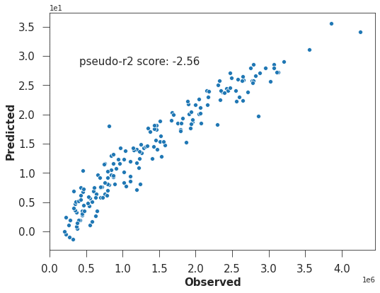

```python
pandas_scatter(df1,'revenue','y_hat', xlab = 'Observed', ylab = 'Predicted', pseudo_R2 = True)
```

If we exectute the function `pandas_scatter`we can have a first measure of the performance. Your scatter plot should be similar to the following one:

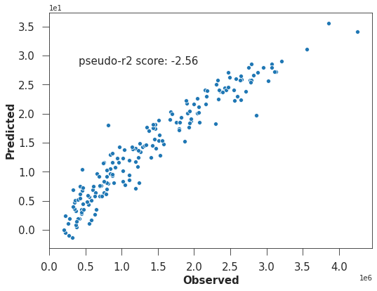

```python
pandas_scatter(df1,'revenue','y_hat', xlab = 'Observed', ylab = 'Predicted', pseudo_R2 = True)
```

[**EX 25**] To measure the performance in the right way, we should split the X and y to generate a X_train, y_train, X_test and y_test (80% for training and 20% for test). Which is the parameter to evaluate a regression model?

```python
X_train, X_test, y_train, y_test = train_test_split(X, y, test_size=.2)

print('The parameter to evaluate a regression model is the R2 value, that shows how much of variability in dependent variable can be explained by the model.')
```

```
The parameter to evaluate a regression model is the R2 value, that shows how much of variability in dependent variable can be explained by the model.
```

[**EX 26**] Train a linear regression model and evaluate the score. Use the function `r2_score(y_actual, y_prediction)`to calculate the R^2 for `y_train` and `y_test`.

```python
from sklearn.linear_model import LinearRegression

Lin_Regr  = LinearRegression()

Lin_Regr.fit(X_train, y_train)
y_predicted = Lin_Regr.predict(X_test)


r2_score(y_test, y_predicted)
```

```
0.8374154092540762
```

## 6. Get the predictions by Census block group, visualize results and generate insights

[**EX 27**] Finally, we can use this model to predict the annual revenue ($) for each block group in Long Island. Make a copy of `stores_enriched`dataframe and store it in `df2`variable and execute the prediction based on the previous trained linear regression model. Store the prediction in a new `revenue_pred`column in `df2` dataframe.

```python
df2 = stores_enriched.copy()

df2['revenue_pred'] = Lin_Regr.predict(df2[filter_col])
df2.head()
```

|  | revenue | geoid | geometry | pc_0 | pc_1 | pc_2 | pc_3 | pc_4 | pc_5 | pc_6 | ... | pc_60 | pc_61 | pc_62 | pc_63 | pc_64 | pc_65 | pc_66 | pc_67 | pc_68 | revenue_pred |
| --- | --- | --- | --- | --- | --- | --- | --- | --- | --- | --- | --- | --- | --- | --- | --- | --- | --- | --- | --- | --- | --- |
| 2672 | 1.016898e+06 | 360810711002 | POLYGON ((-73.85603 40.72346, -73.85670 40.722... | 0.252667 | -1.592204 | -2.028158 | -2.627619 | -1.268654 | -2.726792 | -0.706863 | ... | 0.874447 | 0.443333 | 0.740931 | -0.602890 | 0.191398 | -0.775267 | 0.272021 | 0.522995 | 0.198035 | 10.660760 |
| 2428 | 4.470646e+05 | 360810737002 | POLYGON ((-73.84536 40.71925, -73.84668 40.717... | 0.439377 | 6.139914 | 1.066426 | -3.930415 | -1.268071 | -3.491042 | 0.139864 | ... | 0.446690 | 1.646802 | 0.382731 | -0.911506 | 0.995553 | -1.578721 | 0.276976 | 0.542847 | -0.377862 | 2.906586 |
| 3153 | 7.028071e+05 | 360810645002 | POLYGON ((-73.85714 40.71099, -73.85668 40.707... | 1.074362 | 1.669466 | -0.688634 | -0.664445 | -1.506192 | -1.187679 | 0.058608 | ... | -0.911561 | 0.392867 | 0.169059 | -0.665757 | -0.062881 | -0.449070 | -0.362457 | -0.704930 | 0.388533 | 7.530527 |
| 3737 | 2.831908e+05 | 360810713053 | POLYGON ((-73.85288 40.72638, -73.85351 40.725... | 3.832132 | 7.784235 | -1.892865 | -0.196634 | 0.560720 | -2.850941 | -0.615845 | ... | -1.311534 | 1.884556 | 0.739733 | -0.827812 | -0.552496 | 0.303563 | -0.602510 | -0.577819 | -0.983612 | 2.408051 |
| 463 | 3.672994e+05 | 360810216001 | POLYGON ((-73.82640 40.71565, -73.82698 40.715... | 2.022870 | 4.268485 | 3.309649 | -0.754714 | -0.439542 | -3.008471 | -0.575690 | ... | -1.042494 | 0.752506 | 0.433582 | -1.225601 | -0.535040 | -0.630196 | -0.389563 | -0.117868 | -0.470984 | 4.727256 |

5 rows × 73 columns

[**EX 28**] Create a map visualization with the following characteristics:

- Layer with `df2`and the `revenue_pred`variable. Include also a widget to show a histogram for `revenue_pred`
- Layer with `stores`and the `revenue`variable (similar to **EX7**)
- show_info: True
- viewport: 'zoom': 9.4, 'lat': 40.673790, 'lng': -73.992685
- size: 920, 300

```python
plot_size = (920, 300)

breaks = [400000,700000, 1000000, 1300000, 1600000]
size_bins_st = size_bins_style('revenue', breaks = breaks)
size_bins_leg = size_bins_legend(title='Revenue', description='STARBUCKS', footer='Size of the blob')

viewport = {'zoom': 9.4, 'lat':40.673790, 'lng': -73.992685}

# Map([Layer(df2,style=color_bins_style('revenue_pred'), title='Predicted Revenue',
#          widgets = histogram_widget('revenue_pred', title = 'Histogram of revenue_pred')),
#     Layer( stores, size_bins_st, size_bins_leg, title='Revenue')], size=plot_size, viewport=viewport, show_info=True)
```

```
WARNING: 1 intermediate output message was discarded.
```

[**EX 29**] Select 3 areas where to place a new Starbucks shop. Justify your answer.

```python
print('To place a new Starbucks store, we have to take into consideration the closeness of other Starbucks stores and the Predicted Revenue of the census block, to expect higher benefits.')
print('According to these reasons, I would place Starbucks store in the area of: viewport = {\'zoom\': 9.94, \'lat\':40.858563, \'lng\': -73.596159}, where there are high predicted revenue values and no stores close. Plus the ones closer are on the top break level of revenue')
print('The second one, and following the same procedures, would be placed in the area of: viewport = {\'zoom\': 9.99, \'lat\':40.800242, \'lng\': -73.385038}. And a third one, could be on the end of the island or maybe a better option is within the area of viewport = {\'zoom\': 9.91, \'lat\':40.846007, \'lng\': -72.843293}, since there is a big area without Starbucks stores nearby and the revenue prediction value of the area is pretty high (dark).')
```

[output not shown]

## Upload to Carto to share

If we would like to upload to Carto to share the new visualization, we should apply the following script:

```python
to_carto(df2,'starbucks_long_island_predictions', if_exists = 'replace')
```

## Conclusions

- Using CARTO we were able to explore and visualize the Starbucks data and enrich them using demographics and socioeconomic data from CARTO Data Observatory
- We built a Linear Regression model to predict the stores annual revenue from demographic and socioeconomic covariates, which were first transformed to impute missing data and reduce the model dimensionality.